# KAGGLE

2022-12-09

# Import given data (training set and test set)

```r
data = read.csv(file = 'train.csv')
eval = read.csv(file = 'test.csv')

View(head(data))
View(head(eval))
```

# Cleaning data

```r
colSums(is.na(data))
```

```
##  Appliances      lights          T1        RH_1          T2        RH_2
##           0           0           0           0           0           0
##          T3        RH_3          T4        RH_4          T5        RH_5
##           0           0           0           0           0           0
##          T6        RH_6          T7        RH_7          T8        RH_8
##           0           0           0           0           0           0
##          T9        RH_9       T_out Press_mm_hg      RH_out   Windspeed
##           0           0           0           0           0           0
##  Visibility   Tdewpoint         rv1         rv2 Day_of_week
##           0           0           0           0           0
```

```r
colSums(is.na(eval))
```

```
##      lights          T1        RH_1          T2        RH_2          T3
##           0           0           0           0           0           0
##        RH_3          T4        RH_4          T5        RH_5          T6
##           0           0           0           0           0           0
##        RH_6          T7        RH_7          T8        RH_8          T9
##           0           0           0           0           0           0
##        RH_9       T_out Press_mm_hg      RH_out   Windspeed  Visibility
##           0           0           0           0           0           0
##   Tdewpoint         rv1         rv2 Day_of_week
##           0           0           0           0
```

There is no NA values in the both of the datasets.

```r
data$Day_of_week = factor(data$Day_of_week,
                         levels = c('Monday', 'Tuesday', 'Wednesday', 'Thursday', 'Friday', 'Saturday', 'Sunday'),
                         labels = c(1, 2, 3, 4, 5, 6, 7))
eval$Day_of_week = factor(eval$Day_of_week,
                         levels = c('Monday', 'Tuesday', 'Wednesday', 'Thursday', 'Friday', 'Saturday', 'Sunday'),
                         labels = c(1, 2, 3, 4, 5, 6, 7))
```

# Splitting training and test set

```r
library(caTools)

set.seed(123)
split = sample.split(data$Appliances, SplitRatio = 0.8)


training_set = subset(data, split == TRUE)
test_set = subset(data, split == FALSE)

dim(training_set)
```

```
## [1] 11846    29
```

```r
dim(test_set)
```

```
## [1] 2955   29
```

# Models - basic ones

Function that allows to calculate the root mean square error so that we can see which model is the most effective on predicting the energy appliances.

```r
rmse <- function(yp, y) {
  return(sqrt(mean((yp - y)^2)))
}
```

## Linear regression model // Weak model

```r
linear_model <- lm(Appliances ~., data = training_set)
yplm <- predict(linear_model, newdata = test_set)
RMSE_lm <- rmse(yplm, test_set$Appliances)
summary(linear_model)
```

```
##
## Call:
## lm(formula = Appliances ~ ., data = training_set)
##
## Residuals:
##     Min      1Q  Median      3Q     Max
## -228.60  -43.23  -19.21    6.65  938.63
##
## Coefficients: (1 not defined because of singularities)
##               Estimate Std. Error t value Pr(>|t|)
## (Intercept)  -84.84553  126.94825  -0.668  0.50392
## lights         2.02766    0.12402  16.349  < 2e-16 ***
## T1             1.07230    2.44227   0.439  0.66063
## RH_1          16.72582    0.90366  18.509  < 2e-16 ***
## T2           -18.73170    2.16374  -8.657  < 2e-16 ***
## RH_2         -13.88451    1.01409 -13.692  < 2e-16 ***
## T3            24.63925    1.39419  17.673  < 2e-16 ***
## RH_3           5.09725    0.89843   5.674 1.43e-08 ***
## T4            -2.11439    1.37202  -1.541  0.12332
## RH_4          -0.53933    0.84267  -0.640  0.52217
## T5            -2.16807    1.55322  -1.396  0.16278
## RH_5           0.20491    0.11563   1.772  0.07641 .
## T6             7.10655    0.83801   8.480  < 2e-16 ***
## RH_6           0.32944    0.08914   3.696  0.00022 ***
## T7             1.25496    1.73730   0.722  0.47009
## RH_7          -1.50318    0.56524  -2.659  0.00784 **
## T8             7.08001    1.31401   5.388 7.26e-08 ***
## RH_8          -4.63141    0.49290  -9.396  < 2e-16 ***
## T9           -13.01384    2.33119  -5.582 2.42e-08 ***
## RH_9          -1.30171    0.53859  -2.417  0.01567 *
## T_out         -8.75057    2.03336  -4.304 1.69e-05 ***
## Press_mm_hg    0.23311    0.14283   1.632  0.10268
## RH_out        -0.84251    0.41805  -2.015  0.04389 *
## Windspeed      1.23471    0.46112   2.678  0.00742 **
## Visibility     0.22122    0.07591   2.914  0.00357 **
## Tdewpoint      3.01118    1.97462   1.525  0.12730
## rv1            0.04594    0.06019   0.763  0.44534
## rv2                 NA         NA      NA       NA
## Day_of_week2  -6.27854    3.44089  -1.825  0.06807 .
## Day_of_week3   0.87632    3.37613   0.260  0.79521
## Day_of_week4  -1.79049    3.38458  -0.529  0.59681
## Day_of_week5   8.98076    3.46519   2.592  0.00956 **
## Day_of_week6  13.90783    3.36789   4.130 3.66e-05 ***
## Day_of_week7   7.01187    3.40036   2.062  0.03922 *
## ---
## Signif. codes:  0 '***' 0.001 '**' 0.01 '*' 0.05 '.' 0.1 ' ' 1
##
## Residual standard error: 95.07 on 11813 degrees of freedom
## Multiple R-squared:  0.1704, Adjusted R-squared:  0.1681
## F-statistic: 75.81 on 32 and 11813 DF,  p-value: < 2.2e-16
```

```r
RMSE_lm
```

```
## [1] 91.90281
```

## Decision trees

```r
library(rpart)
decision_trees <- rpart(Appliances ~., data = training_set, method = 'anova')
ypdt = predict(decision_trees, newdata = test_set)
RMSE_dt <- rmse(ypdt, test_set$Appliances)
summary(decision_trees)
```

```
## Call:
## rpart(formula = Appliances ~ ., data = training_set, method = "anova")
##   n= 11846
##
##           CP nsplit rel error    xerror       xstd
## 1 0.04072229      0 1.0000000 1.0001360 0.03699365
## 2 0.02289543      1 0.9592777 0.9595888 0.03555282
## 3 0.01158920      2 0.9363823 0.9387021 0.03494347
## 4 0.01038815      3 0.9247931 0.9351047 0.03447071
## 5 0.01000000      4 0.9144049 0.9311358 0.03438364
##
## Variable importance
## lights RH_out   RH_6   RH_1   RH_8     T9   RH_3   RH_2   RH_4   RH_7   RH_9
##     23     13      7      6      6      6      4      4      4      4      4
##     T7     T8     T6  T_out     T3     T1     T5
##      3      3      3      3      3      2      2
##
## Node number 1: 11846 observations,    complexity param=0.04072229
##   mean=98.21881, MSE=10863.21
##   left son=2 (9099 obs) right son=3 (2747 obs)
##   Primary splits:
##       lights    < 5        to the left,  improve=0.04072229, (0 missing)
##       RH_out    < 80.72222 to the right, improve=0.02314273, (0 missing)
##       T2        < 19.2525  to the left,  improve=0.01898621, (0 missing)
##       RH_6      < 16.77833 to the right, improve=0.01588619, (0 missing)
##       Windspeed < 4.027778 to the left,  improve=0.01140190, (0 missing)
##   Surrogate splits:
##       RH_3 < 46.18167 to the left,  agree=0.774, adj=0.024, (0 split)
##       RH_7 < 48.00278 to the left,  agree=0.773, adj=0.020, (0 split)
##       RH_4 < 48.7241  to the left,  agree=0.772, adj=0.016, (0 split)
##       RH_9 < 51.563   to the left,  agree=0.771, adj=0.012, (0 split)
##       T4   < 15.28167 to the right, agree=0.771, adj=0.011, (0 split)
##
## Node number 2: 9099 observations,    complexity param=0.02289543
##   mean=86.66227, MSE=8236.502
##   left son=4 (6685 obs) right son=5 (2414 obs)
##   Primary splits:
##       RH_out < 70.41667 to the right, improve=0.03931355, (0 missing)
##       RH_6   < 14.44833 to the right, improve=0.03405492, (0 missing)
##       T6     < 10.42071 to the left,  improve=0.02676502, (0 missing)
```

[output cut: 40 more lines]

```
##       RH_4 < 42.545   to the left,  agree=0.946, adj=0.570, (0 split)
##       RH_7 < 39.45667 to the left,  agree=0.943, adj=0.551, (0 split)
##       RH_9 < 43.95    to the left,  agree=0.940, adj=0.525, (0 split)
##
## Node number 6: 2365 observations
##   mean=127.6321, MSE=14773.67
##
## Node number 7: 382 observations
##   mean=191.3874, MSE=32002
##
## Node number 10: 2109 observations
##   mean=107.155, MSE=9860.375
##
## Node number 11: 305 observations
##   mean=181.9672, MSE=30245.31
```

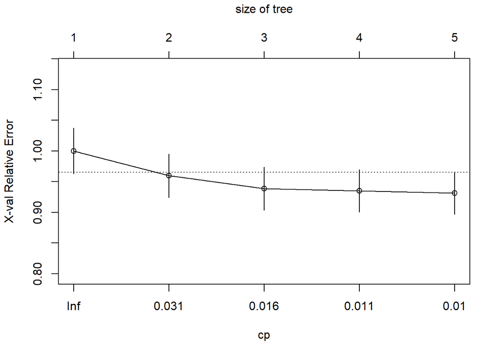

```r
plotcp(decision_trees)
```

```r
RMSE_dt
```

```
## [1] 97.13689
```

## Random forest

```r
library(randomForest)
RF = randomForest(Appliances ~.,training_set, mtry= 6, importance=TRUE)
yprf = predict(RF, newdata = test_set)
RMSE_RF <- rmse(yprf, test_set$Appliances)


importance(RF)
```

```
##               %IncMSE IncNodePurity
## lights      61.964786       5033804
## T1          29.324458       3763729
## RH_1        34.398584       6318375
## T2          29.678999       4802109
## RH_2        24.036380       5378891
## T3          26.128254       5322804
## RH_3        28.367423       5518594
## T4          26.340053       3947412
## RH_4        24.969231       4218820
## T5          28.023109       4154289
## RH_5        29.898412       4887740
## T6          21.665959       4445979
## RH_6        24.282200       5019635
## T7          26.505792       3759772
## RH_7        29.189074       4455241
## T8          30.809300       4436190
## RH_8        33.306740       5310171
## T9          27.440777       3513609
## RH_9        33.090414       4473702
## T_out       21.902781       3787138
## Press_mm_hg 41.073180       5505396
## RH_out      27.867224       5374149
## Windspeed   28.645497       3642506
## Visibility  25.536212       2139210
## Tdewpoint   31.113778       4165792
## rv1          6.846956       2526629
## rv2          5.687655       2488061
## Day_of_week 37.645938       3115125
```

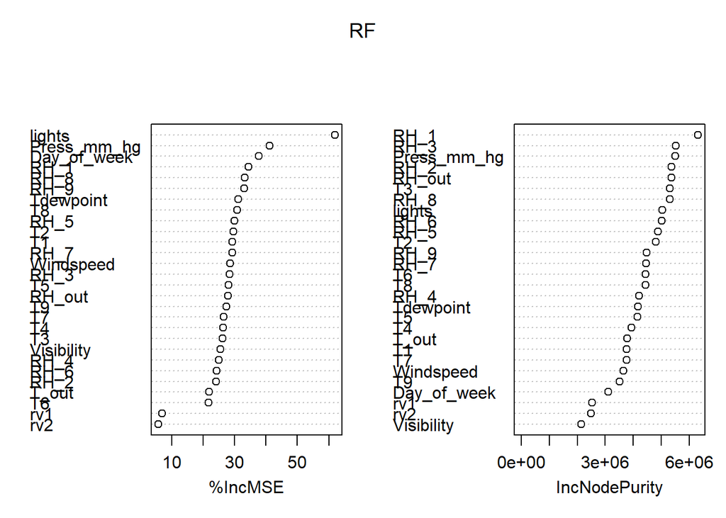

```r
varImpPlot(RF)
```

```r
RMSE_RF
```

```
## [1] 70.70992
```

## Gradient boosting

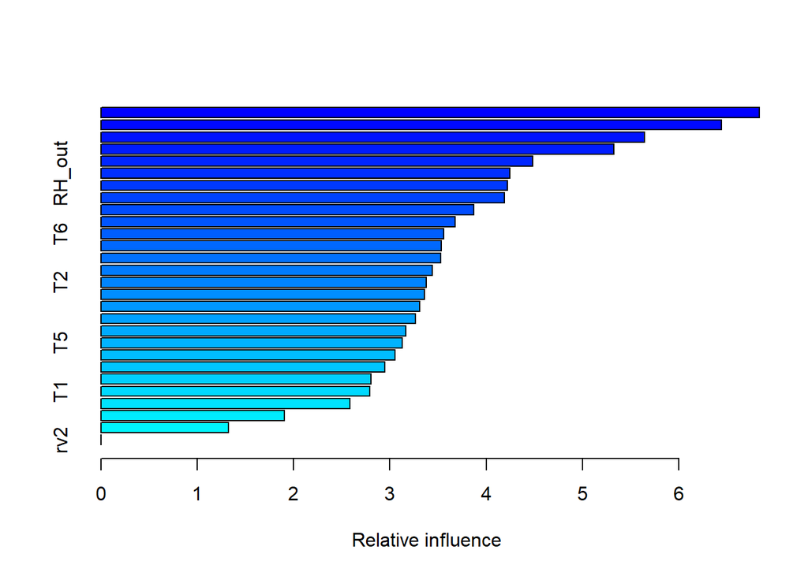

```
##                     var  rel.inf
## Press_mm_hg Press_mm_hg 6.835176
## RH_1               RH_1 6.440568
## RH_2               RH_2 5.645866
## RH_8               RH_8 5.327837
## T3                   T3 4.482738
## RH_out           RH_out 4.244322
## RH_3               RH_3 4.219146
## RH_5               RH_5 4.188625
## RH_6               RH_6 3.870006
## RH_7               RH_7 3.677888
## T6                   T6 3.557036
## lights           lights 3.533460
## Day_of_week Day_of_week 3.526661
## T8                   T8 3.440109
## T2                   T2 3.375351
## RH_9               RH_9 3.358243
## rv1                 rv1 3.307835
## T9                   T9 3.267651
## T4                   T4 3.165994
## T5                   T5 3.129092
## RH_4               RH_4 3.051199
## T7                   T7 2.946194
## Tdewpoint     Tdewpoint 2.803013
## T1                   T1 2.790023
## Windspeed     Windspeed 2.587957
## T_out             T_out 1.905941
## Visibility   Visibility 1.322067
## rv2                 rv2 0.000000
```

```r
library(gbm)
boosting  <- gbm(Appliances ~.,data = training_set, distribution="gaussian", n.trees=5000, interaction.depth = 4)
ypgb <- predict(boosting, newdata = test_set, n.trees=5000)

RMSE_b <- rmse(ypgb, test_set$Appliances)
summary(boosting)
```

```r
RMSE_b
```

```
## [1] 73.26706
```

## Results comparison :

```r
print('RMSE Linear Model:')
```

```
## [1] "RMSE Linear Model:"
```

```r
RMSE_lm
```

```
## [1] 91.90281
```

```r
print('RMSE Decision Trees:')
```

```
## [1] "RMSE Decision Trees:"
```

```r
RMSE_dt
```

```
## [1] 97.13689
```

```r
print('RMSE Random Forest :')
```

```
## [1] "RMSE Random Forest :"
```

```r
RMSE_RF
```

```
## [1] 70.70992
```

```r
print('RMSE Boosting :')
```

```
## [1] "RMSE Boosting :"
```

```r
RMSE_b
```

```
## [1] 73.26706
```

We can see that the best model out of the 4 is the random forest one since it has the lowest RMSE.

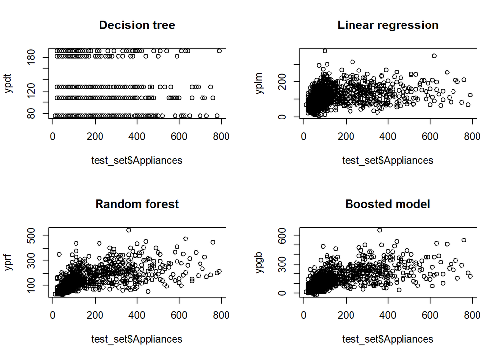

```r
par(mfrow=c(2,2))
plot(test_set$Appliances, ypdt, main='Decision tree')
plot(test_set$Appliances, yplm, main='Linear regression')
plot(test_set$Appliances, yprf, main='Random forest')
plot(test_set$Appliances, ypgb, main='Boosted model')
```

# Feature selection

We make a PCA to visualize the variables’ correlation and identify homogeneous or in the opposite identify specific hidden profiles.

```r
library(FactoMineR)
library(factoextra)
```

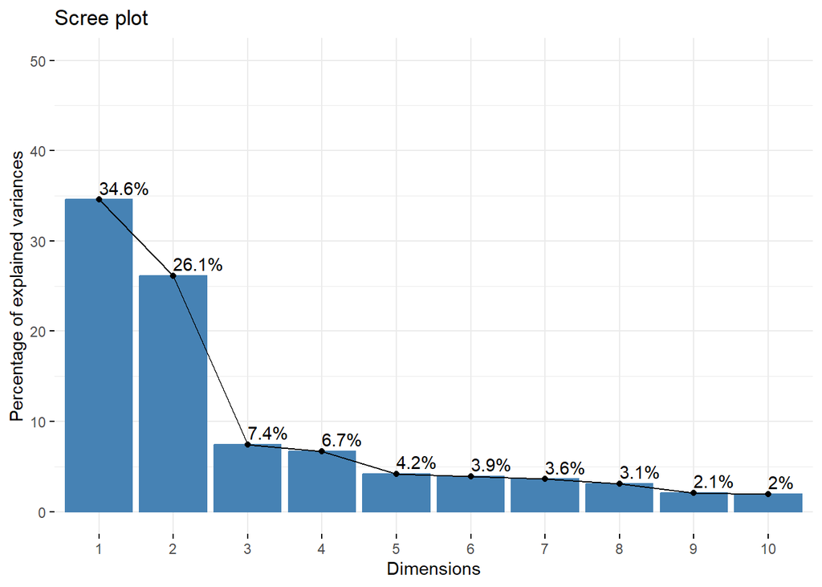

```r
data.active <- data[,2:28]
res.pca <- PCA(data.active, graph = FALSE)
fviz_eig(res.pca, addlabels = TRUE, ylim = c(0,50))
```

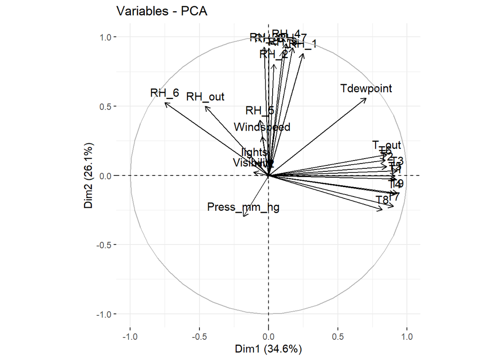

```r
fviz_pca_var(res.pca,col.var = "black")
```

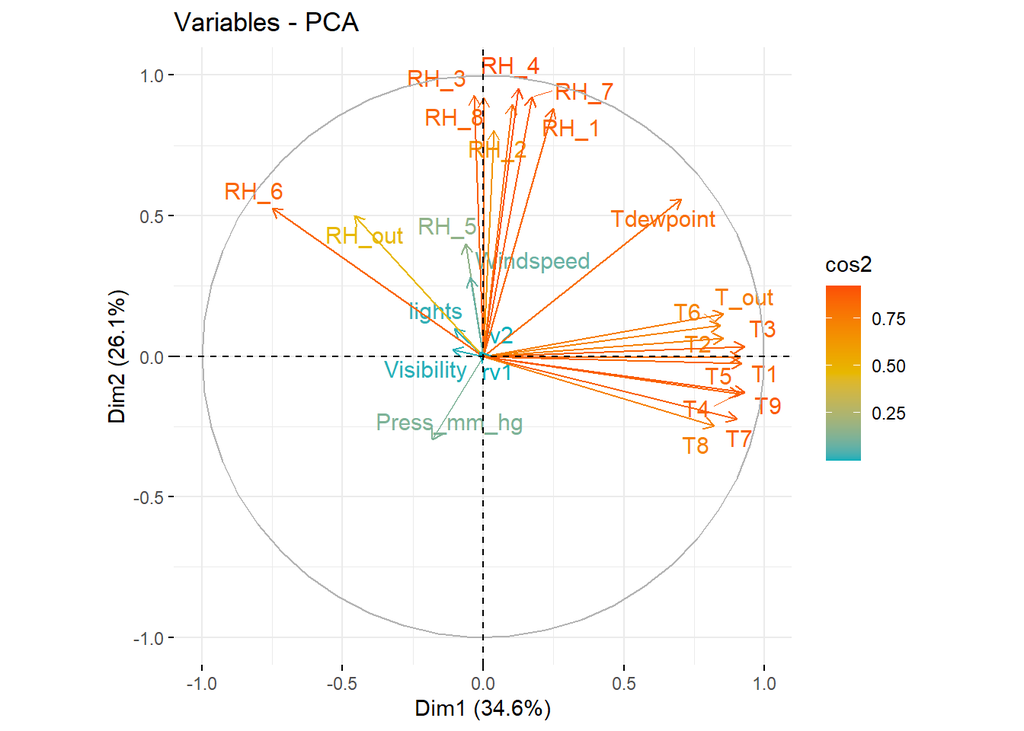

```r
fviz_pca_var(res.pca,col.var = "cos2", gradient.cols = c("#00AFBB","#E7B800","#FC4E07"), repel=TRUE)
```

From this grah, we can notice that we don’t even see rv1 and rv2 arrows. We can also note that lights and visibility are poorly represented but also not correlated. That’s why we decided to remove rv1, rv2, lights and visibility from the features.

### Clusters

We can see that temperatures variables (T1, T2, T3…) are close, and the same goes for humity variables (RH1, RH2…) and RH_6 is isolated from the others.

```r
res.desc<-dimdesc(res.pca,axes=c(1,2),proba=0.05)
res.desc$Dim.1
```

```
##
## Link between the variable and the continuous variables (R-square)
## =================================================================================
##             correlation       p.value
## T9           0.93019446  0.000000e+00
## T3           0.92827232  0.000000e+00
## T1           0.91857075  0.000000e+00
## T5           0.91305301  0.000000e+00
## T4           0.90940565  0.000000e+00
## T7           0.90108475  0.000000e+00
## T_out        0.85358610  0.000000e+00
## T2           0.85252268  0.000000e+00
## T6           0.84236138  0.000000e+00
## T8           0.82076235  0.000000e+00
## Tdewpoint    0.70348933  0.000000e+00
## RH_1         0.24831766 7.856113e-207
## RH_7         0.17314323 5.832949e-100
## RH_4         0.12581186  2.767912e-53
## RH_9         0.10391841  8.042031e-37
## RH_2         0.03766087  4.582738e-06
## RH_3        -0.03207605  9.499727e-05
## Windspeed   -0.04517805  3.826548e-08
## RH_5        -0.06330438  1.271541e-14
## lights      -0.10169051  2.526050e-35
## Visibility  -0.10804612  1.109321e-39
## Press_mm_hg -0.18277236 2.336774e-111
## RH_out      -0.45826166  0.000000e+00
## RH_6        -0.75148411  0.000000e+00
```

```r
res.desc$Dim.2
```

```
##
## Link between the variable and the continuous variables (R-square)
## =================================================================================
##             correlation       p.value
## RH_4         0.95147597  0.000000e+00
## RH_3         0.92772690  0.000000e+00
## RH_7         0.92315673  0.000000e+00
## RH_8         0.91904886  0.000000e+00
## RH_9         0.89650738  0.000000e+00
## RH_1         0.88166146  0.000000e+00
## RH_2         0.80460822  0.000000e+00
## Tdewpoint    0.55937940  0.000000e+00
## RH_6         0.52655597  0.000000e+00
## RH_out       0.49924182  0.000000e+00
## RH_5         0.40072270  0.000000e+00
## Windspeed    0.28053714 8.921176e-266
## T_out        0.14967135  6.810445e-75
## T6           0.11035478  2.489401e-41
## lights       0.09959830  6.005600e-34
## T2           0.06509584  2.240387e-15
## T3           0.03438083  2.868863e-05
## Visibility   0.02226250  6.757819e-03
## T1          -0.02499399  2.358163e-03
## T9          -0.12973665  1.420020e-56
## T4          -0.13407821  2.467190e-60
## T7          -0.22365434 3.635580e-167
## T8          -0.24898983 5.610798e-208
## Press_mm_hg -0.29610558 2.880526e-297
```

RH_out, RH_6, Press_mm_hg, lights and visibility have a negative correlation (that we chose starting from -0.1). The same goes for T9, T4, T7, T8 and Press_mm_hg (the only one that’s negative in both of the dimensions).

# Backward selection

```r
library(MASS)
mod0=lm(Appliances~.,data = data)
backward = stepAIC(mod0, Appliances~., data = data, trace = FALSE, direction = c("backward"))
backward$anova
```

```
## Stepwise Model Path
## Analysis of Deviance Table
##
## Initial Model:
## Appliances ~ lights + T1 + RH_1 + T2 + RH_2 + T3 + RH_3 + T4 +
##     RH_4 + T5 + RH_5 + T6 + RH_6 + T7 + RH_7 + T8 + RH_8 + T9 +
##     RH_9 + T_out + Press_mm_hg + RH_out + Windspeed + Visibility +
##     Tdewpoint + rv1 + rv2 + Day_of_week
##
## Final Model:
## Appliances ~ lights + RH_1 + T2 + RH_2 + T3 + RH_3 + T4 + T5 +
##     RH_5 + T6 + RH_6 + RH_7 + T8 + RH_8 + T9 + RH_9 + T_out +
##     Press_mm_hg + RH_out + Windspeed + Visibility + Tdewpoint +
##     Day_of_week
##
##
##     Step Df   Deviance Resid. Df Resid. Dev      AIC
## 1                          14768  131652640 134654.9
## 2  - rv2  0     0.0000     14768  131652640 134654.9
## 3 - RH_4  1   137.6392     14769  131652778 134652.9
## 4   - T1  1   809.2524     14770  131653587 134651.0
## 5  - rv1  1  2149.9966     14771  131655737 134649.2
## 6   - T7  1 11603.5558     14772  131667341 134648.5
```

We also tried to remove some features using the bacward elimination method but we didn’t have the time to test the subset.

# Training the models without the 4 features we chose to discard

## Linear model

```r
linear_modelbetter <- lm(Appliances ~., data = subset(training_set, select = -c(rv1, rv2, Visibility, lights)))
yplmbetter <- predict(linear_modelbetter, newdata = test_set)
RMSE_lmbetter <- rmse(yplmbetter, test_set$Appliances)
summary(linear_model)
```

```
##
## Call:
## lm(formula = Appliances ~ ., data = training_set)
##
## Residuals:
##     Min      1Q  Median      3Q     Max
## -228.60  -43.23  -19.21    6.65  938.63
##
## Coefficients: (1 not defined because of singularities)
##               Estimate Std. Error t value Pr(>|t|)
## (Intercept)  -84.84553  126.94825  -0.668  0.50392
## lights         2.02766    0.12402  16.349  < 2e-16 ***
## T1             1.07230    2.44227   0.439  0.66063
## RH_1          16.72582    0.90366  18.509  < 2e-16 ***
## T2           -18.73170    2.16374  -8.657  < 2e-16 ***
## RH_2         -13.88451    1.01409 -13.692  < 2e-16 ***
## T3            24.63925    1.39419  17.673  < 2e-16 ***
## RH_3           5.09725    0.89843   5.674 1.43e-08 ***
## T4            -2.11439    1.37202  -1.541  0.12332
## RH_4          -0.53933    0.84267  -0.640  0.52217
## T5            -2.16807    1.55322  -1.396  0.16278
## RH_5           0.20491    0.11563   1.772  0.07641 .
## T6             7.10655    0.83801   8.480  < 2e-16 ***
## RH_6           0.32944    0.08914   3.696  0.00022 ***
## T7             1.25496    1.73730   0.722  0.47009
## RH_7          -1.50318    0.56524  -2.659  0.00784 **
## T8             7.08001    1.31401   5.388 7.26e-08 ***
## RH_8          -4.63141    0.49290  -9.396  < 2e-16 ***
## T9           -13.01384    2.33119  -5.582 2.42e-08 ***
## RH_9          -1.30171    0.53859  -2.417  0.01567 *
## T_out         -8.75057    2.03336  -4.304 1.69e-05 ***
## Press_mm_hg    0.23311    0.14283   1.632  0.10268
## RH_out        -0.84251    0.41805  -2.015  0.04389 *
## Windspeed      1.23471    0.46112   2.678  0.00742 **
## Visibility     0.22122    0.07591   2.914  0.00357 **
## Tdewpoint      3.01118    1.97462   1.525  0.12730
## rv1            0.04594    0.06019   0.763  0.44534
## rv2                 NA         NA      NA       NA
## Day_of_week2  -6.27854    3.44089  -1.825  0.06807 .
## Day_of_week3   0.87632    3.37613   0.260  0.79521
## Day_of_week4  -1.79049    3.38458  -0.529  0.59681
## Day_of_week5   8.98076    3.46519   2.592  0.00956 **
## Day_of_week6  13.90783    3.36789   4.130 3.66e-05 ***
## Day_of_week7   7.01187    3.40036   2.062  0.03922 *
## ---
## Signif. codes:  0 '***' 0.001 '**' 0.01 '*' 0.05 '.' 0.1 ' ' 1
##
## Residual standard error: 95.07 on 11813 degrees of freedom
## Multiple R-squared:  0.1704, Adjusted R-squared:  0.1681
## F-statistic: 75.81 on 32 and 11813 DF,  p-value: < 2.2e-16
```

```r
RMSE_lmbetter
```

```
## [1] 92.81193
```

The RMSE rised, so we cannot say the feature selection was effective on the linear model.

```r
decision_treesbetter <- rpart(Appliances ~., data = subset(training_set, select = -c(rv1, rv2, Visibility, lights)), method = 'anova')
ypdtbetter = predict(decision_treesbetter, newdata = test_set)
RMSE_dtbetter <- rmse(ypdtbetter, test_set$Appliances)
summary(decision_treesbetter)
```

```
## Call:
## rpart(formula = Appliances ~ ., data = subset(training_set, select = -c(rv1,
##     rv2, Visibility, lights)), method = "anova")
##   n= 11846
##
##           CP nsplit rel error    xerror       xstd
## 1 0.02314273      0 1.0000000 1.0000927 0.03699170
## 2 0.01227398      1 0.9768573 0.9775967 0.03638100
## 3 0.01000000      2 0.9645833 0.9658754 0.03586504
##
## Variable importance
## RH_out   RH_2   RH_6   RH_1   RH_4   RH_8   RH_3     T6  T_out   RH_7   RH_9
##     21     13     12     11      7      7      7      6      6      5      5
##
## Node number 1: 11846 observations,    complexity param=0.02314273
##   mean=98.21881, MSE=10863.21
##   left son=2 (6764 obs) right son=3 (5082 obs)
##   Primary splits:
##       RH_out    < 80.72222 to the right, improve=0.02314273, (0 missing)
##       T2        < 19.2525  to the left,  improve=0.01898621, (0 missing)
##       RH_6      < 16.77833 to the right, improve=0.01588619, (0 missing)
##       Windspeed < 4.027778 to the left,  improve=0.01140190, (0 missing)
##       RH_8      < 39.19833 to the right, improve=0.01067982, (0 missing)
##   Surrogate splits:
##       RH_6  < 41.71071 to the right, agree=0.811, adj=0.559, (0 split)
##       RH_2  < 38.19857 to the right, agree=0.719, adj=0.345, (0 split)
##       RH_8  < 40.21843 to the right, agree=0.717, adj=0.340, (0 split)
##       T6    < 10.807   to the left,  agree=0.696, adj=0.291, (0 split)
##       T_out < 10.25    to the left,  agree=0.687, adj=0.270, (0 split)
##
## Node number 2: 6764 observations
##   mean=84.47516, MSE=8238.296
##
## Node number 3: 5082 observations,    complexity param=0.01227398
##   mean=116.5112, MSE=13770.89
##   left son=6 (3330 obs) right son=7 (1752 obs)
##   Primary splits:
##       RH_1 < 40.33167 to the left,  improve=0.02256935, (0 missing)
##       T3   < 23.51667 to the left,  improve=0.01759489, (0 missing)
##       T2   < 19.245   to the left,  improve=0.01469828, (0 missing)
##       RH_3 < 38.796   to the left,  improve=0.01347318, (0 missing)
##       T9   < 24.281   to the left,  improve=0.01176241, (0 missing)
##   Surrogate splits:
##       RH_4 < 39.02458 to the left,  agree=0.890, adj=0.682, (0 split)
##       RH_3 < 38.5375  to the left,  agree=0.872, adj=0.630, (0 split)
##       RH_2 < 40.51343 to the left,  agree=0.850, adj=0.564, (0 split)
##       RH_7 < 34.86524 to the left,  agree=0.828, adj=0.500, (0 split)
##       RH_9 < 41.55571 to the left,  agree=0.820, adj=0.478, (0 split)
##
## Node number 6: 3330 observations
##   mean=103.7237, MSE=9963.431
##
## Node number 7: 1752 observations
##   mean=140.8162, MSE=20106.13
```

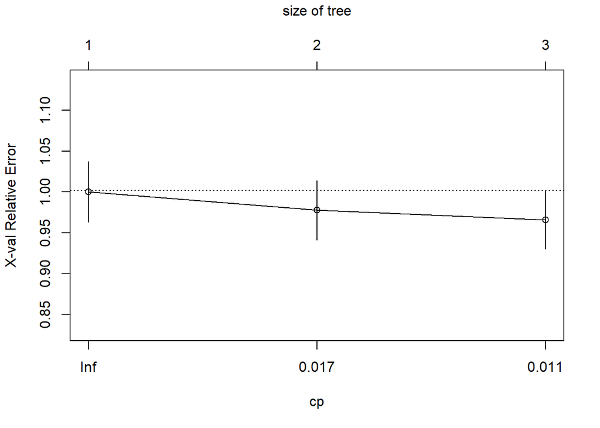

```r
plotcp(decision_treesbetter)
```

```r
RMSE_dtbetter
```

```
## [1] 98.75174
```

RMSE also increased for the decision trees.

```r
RFbetter = randomForest(Appliances ~.,subset(training_set, select = -c(rv1, rv2, Visibility, lights)), mtry= 6, importance=TRUE)
yprfbetter = predict(RFbetter, newdata = test_set)
RMSE_RFbetter <- rmse(yprfbetter, test_set$Appliances)


importance(RFbetter)
```

```
##              %IncMSE IncNodePurity
## T1          31.41831       4221884
## RH_1        36.39259       7142408
## T2          32.94018       5324811
## RH_2        26.25573       5858399
## T3          33.96093       5850847
## RH_3        35.17544       6253183
## T4          29.62230       4587364
## RH_4        30.05336       4816111
## T5          31.44131       4740355
## RH_5        38.73644       5881732
## T6          24.05259       4854896
## RH_6        28.77296       5378586
## T7          28.16926       4417158
## RH_7        30.77371       5060142
## T8          31.97665       4765069
## RH_8        33.02757       6131519
## T9          24.31905       3667388
## RH_9        35.04558       5295410
## T_out       24.11205       4196177
## Press_mm_hg 44.33045       6185789
## RH_out      29.85623       5569453
## Windspeed   26.29405       3790361
## Tdewpoint   25.91716       4718065
## Day_of_week 40.25850       3136077
```

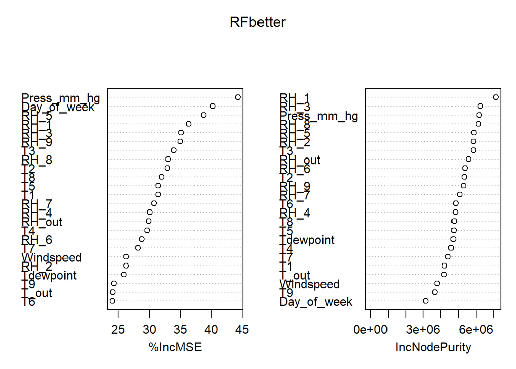

```r
varImpPlot(RFbetter)
```

```r
RMSE_RFbetter
```

```
## [1] 67.99721
```

We can now see that the feature selection decreased the value of the RMSE for the random forest !!

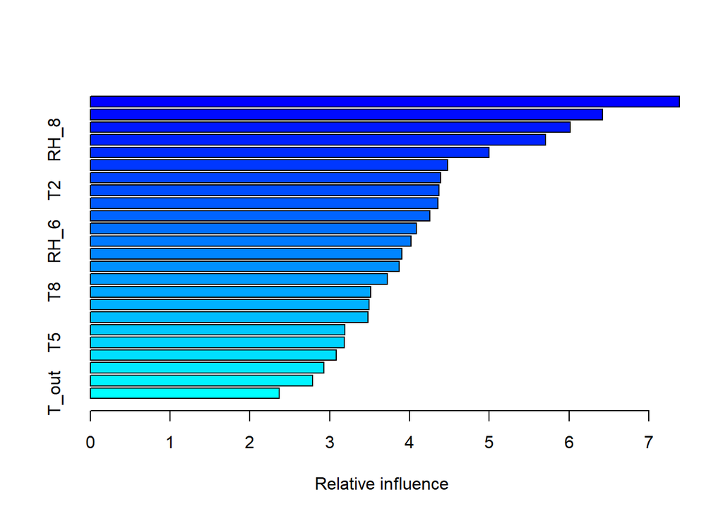

```
##                     var  rel.inf
## Press_mm_hg Press_mm_hg 7.384034
## RH_1               RH_1 6.420757
## RH_2               RH_2 6.013826
## RH_8               RH_8 5.706278
## RH_3               RH_3 4.995568
## T3                   T3 4.479490
## RH_7               RH_7 4.390699
## T2                   T2 4.372380
## RH_5               RH_5 4.354502
## RH_out           RH_out 4.253642
## RH_9               RH_9 4.086137
## RH_6               RH_6 4.017603
## RH_4               RH_4 3.902552
## T4                   T4 3.872885
## T6                   T6 3.719987
## T8                   T8 3.515569
## Day_of_week Day_of_week 3.490769
## T1                   T1 3.481760
## T7                   T7 3.192017
## T5                   T5 3.185098
## Tdewpoint     Tdewpoint 3.085002
## Windspeed     Windspeed 2.928242
## T9                   T9 2.783396
## T_out             T_out 2.367805
```

```r
boostingbetter  <- gbm(Appliances ~.,data = subset(training_set, select = -c(rv1, rv2, Visibility, lights)), distribution="gaussian", n.trees=5000, interaction.depth = 4)
ypgbbetter <- predict(boostingbetter, newdata = test_set, n.trees=5000)

RMSE_bbetter <- rmse(ypgbbetter, test_set$Appliances)
summary(boostingbetter)
```

```r
RMSE_bbetter
```

```
## [1] 72.77116
```

We can now see that the feature selection decreased the value of the RMSE for the boosting too !!

```r
print('RMSE Linear Model without Visibility, lights, rv1 and rv2:')
```

```
## [1] "RMSE Linear Model without Visibility, lights, rv1 and rv2:"
```

```r
RMSE_lmbetter
```

```
## [1] 92.81193
```

```r
print('RMSE Decision Trees without Visibility, lights, rv1 and rv2:')
```

```
## [1] "RMSE Decision Trees without Visibility, lights, rv1 and rv2:"
```

```r
RMSE_dtbetter
```

```
## [1] 98.75174
```

```r
print('RMSE Random Forest without Visibility, lights, rv1 and rv2:')
```

```
## [1] "RMSE Random Forest without Visibility, lights, rv1 and rv2:"
```

```r
RMSE_RFbetter
```

```
## [1] 67.99721
```

```r
print('RMSE Boosting without Visibility, lights, rv1 and rv2:')
```

```
## [1] "RMSE Boosting without Visibility, lights, rv1 and rv2:"
```

```r
RMSE_bbetter
```

```
## [1] 72.77116
```

We can clearly observe the efficiency of the Random Forest model since it has the lowest RMSE. We can now try to find the appropriate hyperparameters to tune the model so that it is even more accurate.

# Tuning the model

To tune the hyperparameters of the random forest, we focus on mtry, and search for its optimal value (with respect to Out-Of-Bag OOB error estimate). We use the tuneRF function.

```
## mtry = 9  OOB error = 159.2791
## Searching left ...
## mtry = 8     OOB error = 168.1093
## -0.05543833 0.01
## Searching right ...
## mtry = 10    OOB error = 97.13134
## 0.3901815 0.01
## mtry = 12    OOB error = 62.66012
## 0.3548929 0.01
## mtry = 14    OOB error = 35.57303
## 0.432286 0.01
## mtry = 16    OOB error = 33.16709
## 0.06763375 0.01
## mtry = 19    OOB error = 19.60169
## 0.4090018 0.01
## mtry = 22    OOB error = 11.7085
## 0.4026792 0.01
## mtry = 26    OOB error = 6.065546
## 0.4819535 0.01
## mtry = 29    OOB error = 4.972991
## 0.1801248 0.01
```

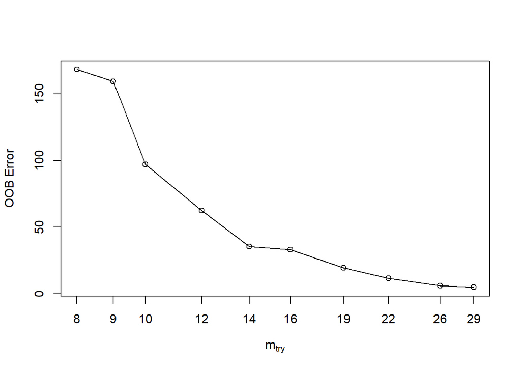

```r
bestmtry <- tuneRF(data, data$Appliances, stepFactor = 1.2, improve = 0.01, trace=T, plot= T)
```

Also, after comparing the models with the data partition, we can fully use the training set (entire dataset that was given to us) as the training set and make the predictions on the test set (that we called eval).

# Making the predictions

Without removing any features : (our last submission but second best only)

```r
RandomForest = randomForest(Appliances ~.,data, mtry = bestmtry, importance=TRUE)
pred = predict(RandomForest, newdata = eval)
```

We think this was the best model.

```r
RandomForestBest = randomForest(Appliances ~.,subset(data, select = -c(rv1, rv2, Visibility, lights)), mtry = bestmtry, importance=TRUE)
pred = predict(RandomForestBest, newdata = eval)
```

# Submission

```r
to_submit = data.frame(id = rownames(eval), Appliances = pred)
write.csv(to_submit , file = "to_be_submitted.csv", row.names = F)
```